# ECDF and Bootstrap Sampling and Applications

Sean Schilk

2/17/26

# Question 1: Asymptotic vs Bootstrap Sampling Distributions

Write an essay summarizing the concepts of Asymptotic and Bootstrap Sampling Distributions, along with their key applications. Your discussion should be grounded in your personal understanding of the material. Any external sources including AI tools consulted must be clearly cited.

Essay Prompt: Discuss the concepts of the bootstrap sampling plan, the bootstrap sampling distribution, and the asymptotic sampling distribution in the context of statistics (e.g., sample mean and variance) computed from an independent and identically distributed (i.i.d.) sample. Your discussion should:

Clearly outline the key assumptions required for each method.

Explain the practical application of each distribution.

Provide guidance on when and why one should be preferred over the other in statistical inference.

Bootstrap sampling is a sampling technique of drawing repeated samples with replacement from a good random sample from a target population. It works best with small to moderate sample sizes, with the assumption the sample represents the population. The goal is to deliver versatile, data-driven inference.

Using that mentioned bootstrap resampling method above, the bootstrap sampling distribution would be a sampling distribution of some statistic of the population, such as a sample mean. For each resample we can take that sample statistic and visually see the probability distribution function of the sample statistic. This works as drawing from the empirical distribution as the empirical distribution converges to the true distribution. Therefore we must keep our resamples the same size as to not artificially shrink estimated standard errors and confidence intervals.

The bootstrap sampling distribution differs from the asymptotic sampling distributions as the ASD is the approximate probability distribution as the sample size n get larger. This has a theoretical, closed-form formula.

The practical upshot is that the bootstrap and asymptotic methods are complementary, not competing. In modern practice, it is common to use asymptotic theory to identify the correct pivot and the bootstrap to estimate its distribution with higher-order accuracy — a synthesis that combines the interpretability of the former with the finite-sample adaptivity of the latter.

# Question 2: Daily Coffee Sales (in mL) at Two Different Cafe Locations

```r
data <- c(2850, 3200, 2900, 3100, 2950, 7800, 8100, 7900, 3300, 3050, 4000, 4200, 3150, 3400, 7700, 8200, 3250, 4400, 3100, 4200, 4500, 4800, 4300, 8500, 8200, 8900, 8700, 3250, 3000, 4600, 4100, 8400, 8800, 3350, 4700, 3100, 8100, 3050, 8300, 4100, 3100, 8300, 8900, 8200, 4400, 4500, 3250, 4600, 8400, 3300, 4200, 4500, 4800, 4300, 8500)
```

We are interested in finding the sampling distribution of sample means that will be used for various inferences about the underlying population mean.

1. Based on the given data, can the Central Limit Theorem be used to derive the asymptotic sampling distribution of the sample mean? Justify your answer.

Yes, as we have a reasonably large sample size of 55, along with finite mean and variance, CLT applies. Therefore our asymptotic sampling distribution of the sample mean would be approximately normal here.

2. Apply the bootstrap method to estimate the sampling distribution (often called the bootstrap sampling distribution) of the sample mean. Generate a kernel density estimate from the bootstrap sample means and plot it. Then, use this bootstrap distribution to validate your conclusion from part (a). Make sure your visuals are effective in enhancing the presentation of these results.

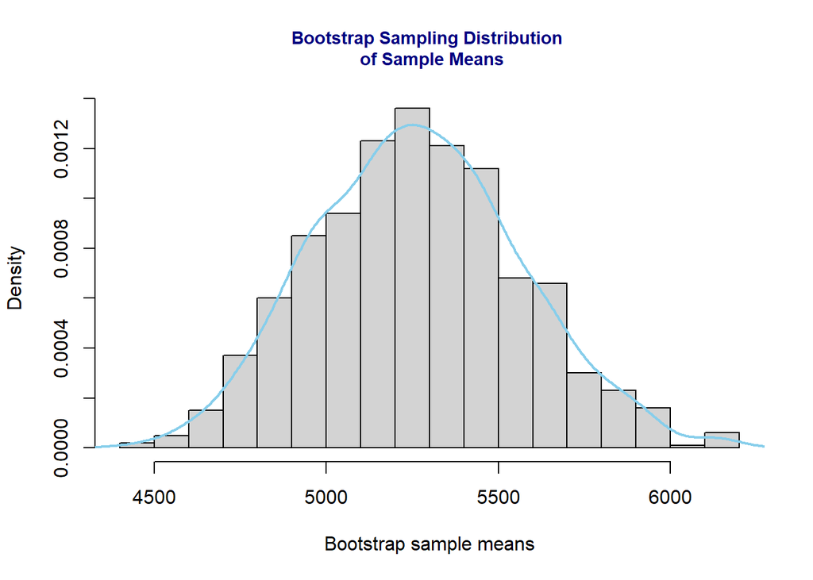

```r
set.seed(1)
original.sample <- data
### Bootstrap sampling begins
bt.sample.mean.vec = NULL      # define an empty vector to hold sample means of repeated samples.
for(i in 1:1000){              # starting for-loop to take bootstrap samples with n = 81
  ith.bt.sample = sample(x = original.sample, # Original sample
                       size = 55,             # sample size = 55 MUST be equal to the sample size!!
                    replace = TRUE            # MUST use WITH REPLACEMENT!!
                       )                      # this is the i-th Bootstrap sample
  bt.sample.mean.vec[i] = mean(ith.bt.sample) # calculate the mean of i-th bootstrap sample and
                                              # save it in the empty vector: sample.bt.mean.vec
}
###
hist(bt.sample.mean.vec,                     # data used for histogram
     breaks = 14,                            # specify number of vertical bars
     probability = TRUE,
       xlab = "Bootstrap sample means",      # change the label of x-axis
      # add a title to the histogram
        main="Bootstrap Sampling Distribution \n of Sample Means",
          cex.main = 0.9,
       col.main = "navy")
lines(density(bt.sample.mean.vec), col = "skyblue", lwd = 2) # KDE
```

As we can see the bootstrap sampling distribution of the sample means is approximately normal.

3. Repeat the analysis in parts (a) and (b) for the sample variance

Since the sample size is reasonably large (n=55) and the population is assumed to have finite variance (and typically a finite fourth moment), the sample variance has an asymptotic normal distribution. Therefore, for a large sample, the sampling distribution of the sample variance can be approximated by a normal distribution.

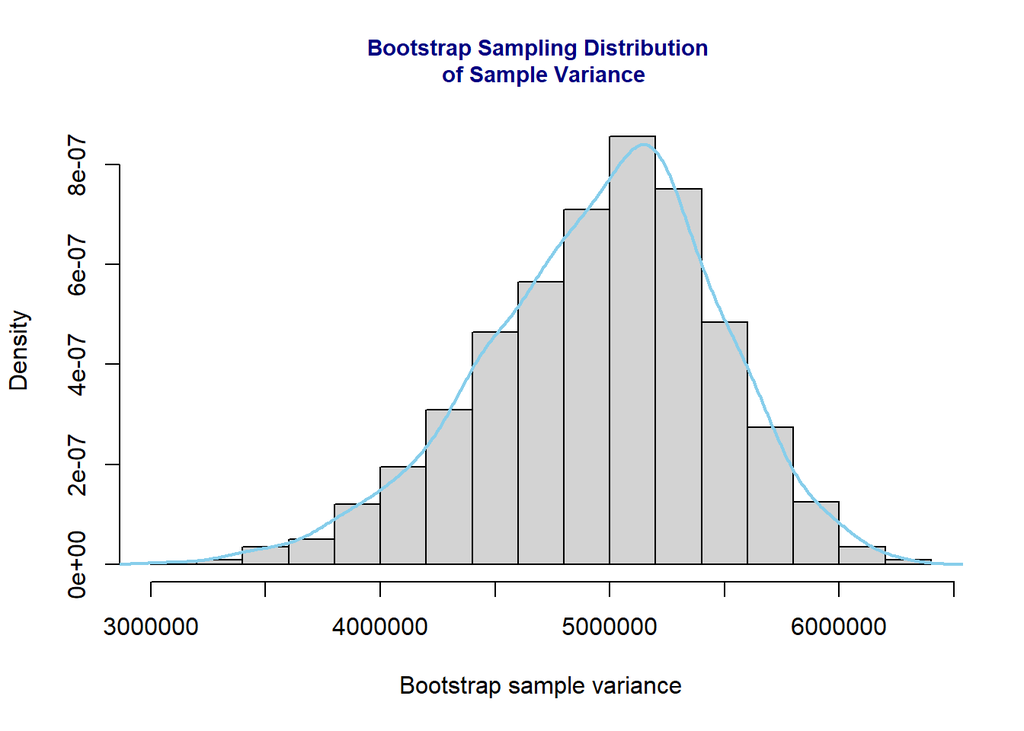

```r
set.seed(1)
### Bootstrap sampling begins
bt.sample.var.vec = NULL      # define an empty vector to hold sample means of repeated samples.
for(i in 1:1000){              # starting for-loop to take bootstrap samples with n = 81
  ith.bt.sample = sample(x = original.sample, # Original sample with 55 WCU students' heights
                       size = 55,             # sample size = 55 MUST be equal to the sample size!!
                    replace = TRUE            # MUST use WITH REPLACEMENT!!
                       )                      # this is the i-th Bootstrap sample
  bt.sample.var.vec[i] = var(ith.bt.sample) # calculate the mean of i-th bootstrap sample and
                                              # save it in the empty vector: sample.bt.mean.vec
}
###
hist(bt.sample.var.vec,                     # data used for histogram
     breaks = 14,                            # specify number of vertical bars
     probability = TRUE,
       xlab = "Bootstrap sample variance",      # change the label of x-axis
      # add a title to the histogram
        main="Bootstrap Sampling Distribution \n of Sample Variance",
          cex.main = 0.9,
       col.main = "navy")
lines(density(bt.sample.var.vec), col = "skyblue", lwd = 2) # KDE
```